# Risk Factor Analysis

## Outcome Variable

**Outcome Variable:** pers_wasted624

## Predictor Variables

**Intervention Variable:** ever_sunderweight06

**Adjustment Set:**

- sex
- arm
- brthmon
- vagbrth
- single
- W_mage
- W_mhtcm
- W_mwtkg
- W_mbmi
- W_meducyrs
- W_feducyrs
- W_parity
- delta_brthmon
- delta_vagbrth
- delta_single
- delta_W_mage
- delta_W_mhtcm
- delta_W_mwtkg
- delta_W_mbmi
- delta_W_meducyrs
- delta_W_feducyrs
- delta_W_parity

## Stratifying Variables

The analysis was stratified on these variable(s):

- studyid
- country

## Data Summary

| studyid | country | ever_sunderweight06 | pers_wasted624 | n_cell | n |
| --- | --- | --- | --- | --- | --- |
| ki0047075b-MAL-ED | BANGLADESH | 0 | 0 | 210 | 240 |
| ki0047075b-MAL-ED | BANGLADESH | 0 | 1 | 14 | 240 |
| ki0047075b-MAL-ED | BANGLADESH | 1 | 0 | 13 | 240 |
| ki0047075b-MAL-ED | BANGLADESH | 1 | 1 | 3 | 240 |
| ki0047075b-MAL-ED | BRAZIL | 0 | 0 | 201 | 207 |
| ki0047075b-MAL-ED | BRAZIL | 0 | 1 | 2 | 207 |
| ki0047075b-MAL-ED | BRAZIL | 1 | 0 | 4 | 207 |
| ki0047075b-MAL-ED | BRAZIL | 1 | 1 | 0 | 207 |
| ki0047075b-MAL-ED | INDIA | 0 | 0 | 187 | 235 |
| ki0047075b-MAL-ED | INDIA | 0 | 1 | 17 | 235 |
| ki0047075b-MAL-ED | INDIA | 1 | 0 | 20 | 235 |
| ki0047075b-MAL-ED | INDIA | 1 | 1 | 11 | 235 |
| ki0047075b-MAL-ED | NEPAL | 0 | 0 | 221 | 235 |
| ki0047075b-MAL-ED | NEPAL | 0 | 1 | 1 | 235 |
| ki0047075b-MAL-ED | NEPAL | 1 | 0 | 12 | 235 |
| ki0047075b-MAL-ED | NEPAL | 1 | 1 | 1 | 235 |
| ki0047075b-MAL-ED | PERU | 0 | 0 | 259 | 270 |
| ki0047075b-MAL-ED | PERU | 0 | 1 | 2 | 270 |
| ki0047075b-MAL-ED | PERU | 1 | 0 | 8 | 270 |
| ki0047075b-MAL-ED | PERU | 1 | 1 | 1 | 270 |
| ki0047075b-MAL-ED | SOUTH AFRICA | 0 | 0 | 246 | 259 |
| ki0047075b-MAL-ED | SOUTH AFRICA | 0 | 1 | 1 | 259 |
| ki0047075b-MAL-ED | SOUTH AFRICA | 1 | 0 | 11 | 259 |
| ki0047075b-MAL-ED | SOUTH AFRICA | 1 | 1 | 1 | 259 |
| ki0047075b-MAL-ED | TANZANIA, UNITED REPUBLIC OF | 0 | 0 | 237 | 245 |
| ki0047075b-MAL-ED | TANZANIA, UNITED REPUBLIC OF | 0 | 1 | 0 | 245 |
| ki0047075b-MAL-ED | TANZANIA, UNITED REPUBLIC OF | 1 | 0 | 8 | 245 |
| ki0047075b-MAL-ED | TANZANIA, UNITED REPUBLIC OF | 1 | 1 | 0 | 245 |
| ki1000108-CMC-V-BCS-2002 | INDIA | 0 | 0 | 285 | 373 |
| ki1000108-CMC-V-BCS-2002 | INDIA | 0 | 1 | 12 | 373 |

[output cut: 90 more lines]

The following strata were considered:

- studyid: ki0047075b-MAL-ED, country: BANGLADESH
- studyid: ki0047075b-MAL-ED, country: BRAZIL
- studyid: ki0047075b-MAL-ED, country: INDIA
- studyid: ki0047075b-MAL-ED, country: NEPAL
- studyid: ki0047075b-MAL-ED, country: PERU
- studyid: ki0047075b-MAL-ED, country: SOUTH AFRICA
- studyid: ki0047075b-MAL-ED, country: TANZANIA, UNITED REPUBLIC OF
- studyid: ki1000108-CMC-V-BCS-2002, country: INDIA
- studyid: ki1000108-IRC, country: INDIA
- studyid: ki1000109-EE, country: PAKISTAN
- studyid: ki1000109-ResPak, country: PAKISTAN
- studyid: ki1000304b-SAS-CompFeed, country: INDIA
- studyid: ki1000304b-SAS-FoodSuppl, country: INDIA
- studyid: ki1017093-NIH-Birth, country: BANGLADESH
- studyid: ki1017093b-PROVIDE, country: BANGLADESH
- studyid: ki1017093c-NIH-Crypto, country: BANGLADESH
- studyid: ki1066203-TanzaniaChild2, country: TANZANIA, UNITED REPUBLIC OF
- studyid: ki1101329-Keneba, country: GAMBIA
- studyid: ki1112895-Guatemala BSC, country: GUATEMALA
- studyid: ki1113344-GMS-Nepal, country: NEPAL
- studyid: ki1114097-CMIN, country: BANGLADESH
- studyid: ki1114097-CONTENT, country: PERU
- studyid: ki1119695-PROBIT, country: BELARUS
- studyid: ki1126311-ZVITAMBO, country: ZIMBABWE
- studyid: ki1135781-COHORTS, country: GUATEMALA
- studyid: ki1135781-COHORTS, country: INDIA
- studyid: ki1135781-COHORTS, country: PHILIPPINES
- studyid: ki1148112-LCNI-5, country: MALAWI
- studyid: kiGH5241-JiVitA-3, country: BANGLADESH
- studyid: kiGH5241-JiVitA-4, country: BANGLADESH

### Dropped Strata

Some strata were dropped due to rare outcomes:

- studyid: ki0047075b-MAL-ED, country: BANGLADESH
- studyid: ki0047075b-MAL-ED, country: BRAZIL
- studyid: ki0047075b-MAL-ED, country: NEPAL
- studyid: ki0047075b-MAL-ED, country: PERU
- studyid: ki0047075b-MAL-ED, country: SOUTH AFRICA
- studyid: ki0047075b-MAL-ED, country: TANZANIA, UNITED REPUBLIC OF
- studyid: ki1112895-Guatemala BSC, country: GUATEMALA
- studyid: ki1114097-CONTENT, country: PERU
- studyid: ki1119695-PROBIT, country: BELARUS

## Methods Detail

We’re interested in the causal parameters $E[Y_a]$ for all values of $a \in \mathcal{A}$. These parameters represent the mean outcome if, possibly contrary to fact, we intervened to set all units to have $A=a$. Under the randomization and positivity assumptions, these are identified by the statistical parameters $\psi_a=E_W[E_{Y|A,W}(Y|A=a,W)]$. In addition, we’re interested in the mean of $Y$, $E[Y]$ under no intervention (the observed mean). We will estimate these parameters by using SuperLearner to fit the relevant likelihood factors – $E_{Y|A,W}(Y|A=a,W)$ and $p(A=a|W)$, and then updating our likelihood fit using a joint TMLE.

For unadjusted analyses ($W=\{\}$), initial likelihoods were estimated using Lrnr_glm to estimate the simple $E(Y|A)$ and Lrnr_mean to estimate $p(A)$. For adjusted analyses, a small library containing Lrnr_glmnet, Lrnr_xgboost, and Lrnr_mean was used.

Having estimated these parameters, we will then use the delta method to estimate relative risks and attributable risks relative to a prespecified baseline level of $A$.

# Results Detail

## Results Plots

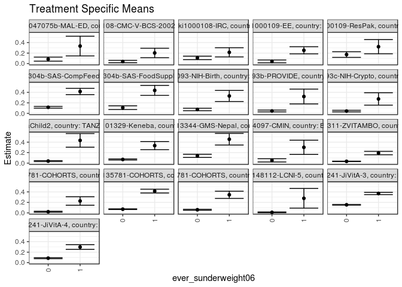

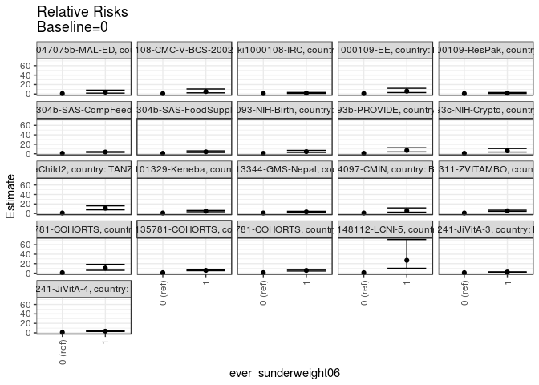

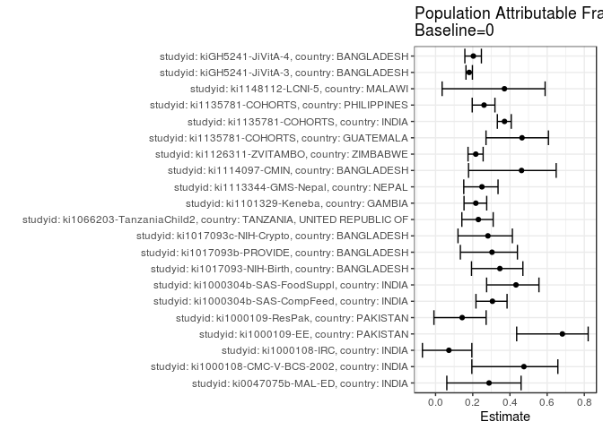

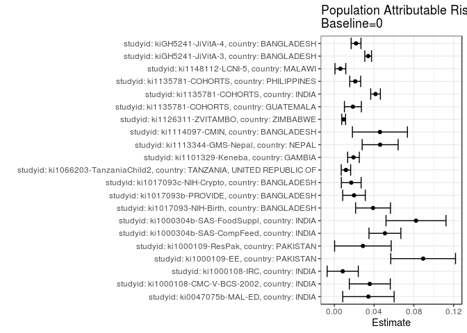

## Results Table

### Parameter: TSM

| studyid | country | intervention_level | baseline_level | estimate | ci_lower | ci_upper |
| --- | --- | --- | --- | --- | --- | --- |
| ki0047075b-MAL-ED | INDIA | 0 | NA | 0.0848760 | 0.0462905 | 0.1234615 |
| ki0047075b-MAL-ED | INDIA | 1 | NA | 0.3341364 | 0.1464441 | 0.5218287 |
| ki1000108-CMC-V-BCS-2002 | INDIA | 0 | NA | 0.0394017 | 0.0169724 | 0.0618310 |
| ki1000108-CMC-V-BCS-2002 | INDIA | 1 | NA | 0.2025808 | 0.1121601 | 0.2930015 |
| ki1000108-IRC | INDIA | 0 | NA | 0.1086777 | 0.0758891 | 0.1414663 |
| ki1000108-IRC | INDIA | 1 | NA | 0.2143086 | 0.1267670 | 0.3018503 |
| ki1000109-EE | PAKISTAN | 0 | NA | 0.0416667 | 0.0149824 | 0.0683509 |
| ki1000109-EE | PAKISTAN | 1 | NA | 0.2531646 | 0.1852731 | 0.3210560 |
| ki1000109-ResPak | PAKISTAN | 0 | NA | 0.1721287 | 0.1181948 | 0.2260627 |
| ki1000109-ResPak | PAKISTAN | 1 | NA | 0.3217940 | 0.1863126 | 0.4572753 |
| ki1000304b-SAS-CompFeed | INDIA | 0 | NA | 0.1154309 | 0.0987201 | 0.1321418 |
| ki1000304b-SAS-CompFeed | INDIA | 1 | NA | 0.4163051 | 0.3557927 | 0.4768174 |
| ki1000304b-SAS-FoodSuppl | INDIA | 0 | NA | 0.1078238 | 0.0722728 | 0.1433748 |
| ki1000304b-SAS-FoodSuppl | INDIA | 1 | NA | 0.4375307 | 0.3423432 | 0.5327181 |
| ki1017093-NIH-Birth | BANGLADESH | 0 | NA | 0.0736175 | 0.0497414 | 0.0974937 |
| ki1017093-NIH-Birth | BANGLADESH | 1 | NA | 0.3312336 | 0.2256524 | 0.4368149 |
| ki1017093b-PROVIDE | BANGLADESH | 0 | NA | 0.0452995 | 0.0282442 | 0.0623547 |
| ki1017093b-PROVIDE | BANGLADESH | 1 | NA | 0.3206655 | 0.1797169 | 0.4616141 |
| ki1017093c-NIH-Crypto | BANGLADESH | 0 | NA | 0.0432992 | 0.0279832 | 0.0586152 |
| ki1017093c-NIH-Crypto | BANGLADESH | 1 | NA | 0.2743652 | 0.1563575 | 0.3923729 |
| ki1066203-TanzaniaChild2 | TANZANIA, UNITED REPUBLIC OF | 0 | NA | 0.0389086 | 0.0303409 | 0.0474763 |
| ki1066203-TanzaniaChild2 | TANZANIA, UNITED REPUBLIC OF | 1 | NA | 0.4327379 | 0.3030659 | 0.5624099 |
| ki1101329-Keneba | GAMBIA | 0 | NA | 0.0696576 | 0.0591260 | 0.0801893 |
| ki1101329-Keneba | GAMBIA | 1 | NA | 0.3334521 | 0.2555885 | 0.4113157 |
| ki1113344-GMS-Nepal | NEPAL | 0 | NA | 0.1386601 | 0.1085603 | 0.1687599 |
| ki1113344-GMS-Nepal | NEPAL | 1 | NA | 0.4547440 | 0.3448747 | 0.5646132 |
| ki1114097-CMIN | BANGLADESH | 0 | NA | 0.0533383 | 0.0224168 | 0.0842598 |
| ki1114097-CMIN | BANGLADESH | 1 | NA | 0.3011830 | 0.1656712 | 0.4366947 |
| ki1126311-ZVITAMBO | ZIMBABWE | 0 | NA | 0.0339184 | 0.0304169 | 0.0374198 |
| ki1126311-ZVITAMBO | ZIMBABWE | 1 | NA | 0.1918797 | 0.1590619 | 0.2246975 |
| ki1135781-COHORTS | GUATEMALA | 0 | NA | 0.0214463 | 0.0120662 | 0.0308263 |
| ki1135781-COHORTS | GUATEMALA | 1 | NA | 0.2264650 | 0.1456261 | 0.3073039 |
| ki1135781-COHORTS | INDIA | 0 | NA | 0.0703429 | 0.0638964 | 0.0767895 |
| ki1135781-COHORTS | INDIA | 1 | NA | 0.4151821 | 0.3794490 | 0.4509152 |
| ki1135781-COHORTS | PHILIPPINES | 0 | NA | 0.0594783 | 0.0504339 | 0.0685228 |
| ki1135781-COHORTS | PHILIPPINES | 1 | NA | 0.3446947 | 0.2755155 | 0.4138738 |
| ki1148112-LCNI-5 | MALAWI | 0 | NA | 0.0102828 | 0.0031722 | 0.0173933 |
| ki1148112-LCNI-5 | MALAWI | 1 | NA | 0.2777778 | 0.0904991 | 0.4650565 |
| kiGH5241-JiVitA-3 | BANGLADESH | 0 | NA | 0.1538940 | 0.1474033 | 0.1603847 |
| kiGH5241-JiVitA-3 | BANGLADESH | 1 | NA | 0.3695881 | 0.3477336 | 0.3914427 |
| kiGH5241-JiVitA-4 | BANGLADESH | 0 | NA | 0.0855362 | 0.0755905 | 0.0954818 |
| kiGH5241-JiVitA-4 | BANGLADESH | 1 | NA | 0.2973126 | 0.2530177 | 0.3416076 |

### Parameter: E(Y)

| studyid | country | intervention_level | baseline_level | estimate | ci_lower | ci_upper |
| --- | --- | --- | --- | --- | --- | --- |
| ki0047075b-MAL-ED | INDIA | NA | NA | 0.1191489 | 0.0776405 | 0.1606574 |
| ki1000108-CMC-V-BCS-2002 | INDIA | NA | NA | 0.0750670 | 0.0482904 | 0.1018437 |
| ki1000108-IRC | INDIA | NA | NA | 0.1170732 | 0.0859146 | 0.1482317 |
| ki1000109-EE | PAKISTAN | NA | NA | 0.1310160 | 0.0967738 | 0.1652583 |
| ki1000109-ResPak | PAKISTAN | NA | NA | 0.2008547 | 0.1494120 | 0.2522974 |
| ki1000304b-SAS-CompFeed | INDIA | NA | NA | 0.1663067 | 0.1478935 | 0.1847199 |
| ki1000304b-SAS-FoodSuppl | INDIA | NA | NA | 0.1900000 | 0.1515071 | 0.2284929 |
| ki1017093-NIH-Birth | BANGLADESH | NA | NA | 0.1125461 | 0.0859151 | 0.1391771 |
| ki1017093b-PROVIDE | BANGLADESH | NA | NA | 0.0650407 | 0.0455353 | 0.0845460 |
| ki1017093c-NIH-Crypto | BANGLADESH | NA | NA | 0.0602740 | 0.0429977 | 0.0775502 |
| ki1066203-TanzaniaChild2 | TANZANIA, UNITED REPUBLIC OF | NA | NA | 0.0505451 | 0.0409848 | 0.0601054 |
| ki1101329-Keneba | GAMBIA | NA | NA | 0.0888980 | 0.0776057 | 0.1001903 |
| ki1113344-GMS-Nepal | NEPAL | NA | NA | 0.1847458 | 0.1534039 | 0.2160876 |
| ki1114097-CMIN | BANGLADESH | NA | NA | 0.0992063 | 0.0622241 | 0.1361886 |
| ki1126311-ZVITAMBO | ZIMBABWE | NA | NA | 0.0432772 | 0.0394419 | 0.0471125 |
| ki1135781-COHORTS | GUATEMALA | NA | NA | 0.0400782 | 0.0280529 | 0.0521035 |
| ki1135781-COHORTS | INDIA | NA | NA | 0.1117877 | 0.1043506 | 0.1192249 |
| ki1135781-COHORTS | PHILIPPINES | NA | NA | 0.0804557 | 0.0703953 | 0.0905161 |
| ki1148112-LCNI-5 | MALAWI | NA | NA | 0.0163317 | 0.0075211 | 0.0251422 |
| kiGH5241-JiVitA-3 | BANGLADESH | NA | NA | 0.1879125 | 0.1813641 | 0.1944608 |
| kiGH5241-JiVitA-4 | BANGLADESH | NA | NA | 0.1073532 | 0.0971813 | 0.1175251 |

### Parameter: RR

| studyid | country | intervention_level | baseline_level | estimate | ci_lower | ci_upper |
| --- | --- | --- | --- | --- | --- | --- |
| ki0047075b-MAL-ED | INDIA | 0 | 0 | 1.000000 | 1.000000 | 1.000000 |
| ki0047075b-MAL-ED | INDIA | 1 | 0 | 3.936759 | 1.908082 | 8.122329 |
| ki1000108-CMC-V-BCS-2002 | INDIA | 0 | 0 | 1.000000 | 1.000000 | 1.000000 |
| ki1000108-CMC-V-BCS-2002 | INDIA | 1 | 0 | 5.141425 | 2.487916 | 10.625055 |
| ki1000108-IRC | INDIA | 0 | 0 | 1.000000 | 1.000000 | 1.000000 |
| ki1000108-IRC | INDIA | 1 | 0 | 1.971965 | 1.185102 | 3.281277 |
| ki1000109-EE | PAKISTAN | 0 | 0 | 1.000000 | 1.000000 | 1.000000 |
| ki1000109-EE | PAKISTAN | 1 | 0 | 6.075949 | 3.034465 | 12.165950 |
| ki1000109-ResPak | PAKISTAN | 0 | 0 | 1.000000 | 1.000000 | 1.000000 |
| ki1000109-ResPak | PAKISTAN | 1 | 0 | 1.869496 | 1.108691 | 3.152379 |
| ki1000304b-SAS-CompFeed | INDIA | 0 | 0 | 1.000000 | 1.000000 | 1.000000 |
| ki1000304b-SAS-CompFeed | INDIA | 1 | 0 | 3.606530 | 2.912688 | 4.465655 |
| ki1000304b-SAS-FoodSuppl | INDIA | 0 | 0 | 1.000000 | 1.000000 | 1.000000 |
| ki1000304b-SAS-FoodSuppl | INDIA | 1 | 0 | 4.057830 | 2.729954 | 6.031599 |
| ki1017093-NIH-Birth | BANGLADESH | 0 | 0 | 1.000000 | 1.000000 | 1.000000 |
| ki1017093-NIH-Birth | BANGLADESH | 1 | 0 | 4.499386 | 2.854475 | 7.092188 |
| ki1017093b-PROVIDE | BANGLADESH | 0 | 0 | 1.000000 | 1.000000 | 1.000000 |
| ki1017093b-PROVIDE | BANGLADESH | 1 | 0 | 7.078794 | 3.964949 | 12.638076 |
| ki1017093c-NIH-Crypto | BANGLADESH | 0 | 0 | 1.000000 | 1.000000 | 1.000000 |
| ki1017093c-NIH-Crypto | BANGLADESH | 1 | 0 | 6.336492 | 3.625617 | 11.074289 |
| ki1066203-TanzaniaChild2 | TANZANIA, UNITED REPUBLIC OF | 0 | 0 | 1.000000 | 1.000000 | 1.000000 |
| ki1066203-TanzaniaChild2 | TANZANIA, UNITED REPUBLIC OF | 1 | 0 | 11.121909 | 7.666669 | 16.134368 |
| ki1101329-Keneba | GAMBIA | 0 | 0 | 1.000000 | 1.000000 | 1.000000 |
| ki1101329-Keneba | GAMBIA | 1 | 0 | 4.787013 | 3.626177 | 6.319465 |
| ki1113344-GMS-Nepal | NEPAL | 0 | 0 | 1.000000 | 1.000000 | 1.000000 |
| ki1113344-GMS-Nepal | NEPAL | 1 | 0 | 3.279559 | 2.372997 | 4.532457 |
| ki1114097-CMIN | BANGLADESH | 0 | 0 | 1.000000 | 1.000000 | 1.000000 |
| ki1114097-CMIN | BANGLADESH | 1 | 0 | 5.646657 | 2.711387 | 11.759565 |
| ki1126311-ZVITAMBO | ZIMBABWE | 0 | 0 | 1.000000 | 1.000000 | 1.000000 |
| ki1126311-ZVITAMBO | ZIMBABWE | 1 | 0 | 5.657103 | 4.633492 | 6.906846 |
| ki1135781-COHORTS | GUATEMALA | 0 | 0 | 1.000000 | 1.000000 | 1.000000 |
| ki1135781-COHORTS | GUATEMALA | 1 | 0 | 10.559653 | 6.020679 | 18.520547 |
| ki1135781-COHORTS | INDIA | 0 | 0 | 1.000000 | 1.000000 | 1.000000 |
| ki1135781-COHORTS | INDIA | 1 | 0 | 5.902257 | 5.206436 | 6.691071 |
| ki1135781-COHORTS | PHILIPPINES | 0 | 0 | 1.000000 | 1.000000 | 1.000000 |
| ki1135781-COHORTS | PHILIPPINES | 1 | 0 | 5.795298 | 4.508260 | 7.449764 |
| ki1148112-LCNI-5 | MALAWI | 0 | 0 | 1.000000 | 1.000000 | 1.000000 |
| ki1148112-LCNI-5 | MALAWI | 1 | 0 | 27.013889 | 10.283843 | 70.960844 |
| kiGH5241-JiVitA-3 | BANGLADESH | 0 | 0 | 1.000000 | 1.000000 | 1.000000 |
| kiGH5241-JiVitA-3 | BANGLADESH | 1 | 0 | 2.401576 | 2.234594 | 2.581036 |
| kiGH5241-JiVitA-4 | BANGLADESH | 0 | 0 | 1.000000 | 1.000000 | 1.000000 |
| kiGH5241-JiVitA-4 | BANGLADESH | 1 | 0 | 3.475871 | 2.871893 | 4.206869 |

### Parameter: PAR

| studyid | country | intervention_level | baseline_level | estimate | ci_lower | ci_upper |
| --- | --- | --- | --- | --- | --- | --- |
| ki0047075b-MAL-ED | INDIA | 0 | NA | 0.0342729 | 0.0084107 | 0.0601351 |
| ki1000108-CMC-V-BCS-2002 | INDIA | 0 | NA | 0.0356653 | 0.0150303 | 0.0563004 |
| ki1000108-IRC | INDIA | 0 | NA | 0.0083955 | -0.0072739 | 0.0240649 |
| ki1000109-EE | PAKISTAN | 0 | NA | 0.0893494 | 0.0567594 | 0.1219393 |
| ki1000109-ResPak | PAKISTAN | 0 | NA | 0.0287260 | 0.0002329 | 0.0572190 |
| ki1000304b-SAS-CompFeed | INDIA | 0 | NA | 0.0508758 | 0.0348179 | 0.0669337 |
| ki1000304b-SAS-FoodSuppl | INDIA | 0 | NA | 0.0821762 | 0.0519772 | 0.1123752 |
| ki1017093-NIH-Birth | BANGLADESH | 0 | NA | 0.0389286 | 0.0213765 | 0.0564807 |
| ki1017093b-PROVIDE | BANGLADESH | 0 | NA | 0.0197412 | 0.0083631 | 0.0311193 |
| ki1017093c-NIH-Crypto | BANGLADESH | 0 | NA | 0.0169747 | 0.0070339 | 0.0269156 |
| ki1066203-TanzaniaChild2 | TANZANIA, UNITED REPUBLIC OF | 0 | NA | 0.0116365 | 0.0068899 | 0.0163831 |
| ki1101329-Keneba | GAMBIA | 0 | NA | 0.0192404 | 0.0133739 | 0.0251068 |
| ki1113344-GMS-Nepal | NEPAL | 0 | NA | 0.0460857 | 0.0279731 | 0.0641982 |
| ki1114097-CMIN | BANGLADESH | 0 | NA | 0.0458681 | 0.0181718 | 0.0735643 |
| ki1126311-ZVITAMBO | ZIMBABWE | 0 | NA | 0.0093589 | 0.0074266 | 0.0112912 |
| ki1135781-COHORTS | GUATEMALA | 0 | NA | 0.0186320 | 0.0101030 | 0.0271609 |
| ki1135781-COHORTS | INDIA | 0 | NA | 0.0414448 | 0.0365676 | 0.0463220 |
| ki1135781-COHORTS | PHILIPPINES | 0 | NA | 0.0209773 | 0.0154850 | 0.0264697 |
| ki1148112-LCNI-5 | MALAWI | 0 | NA | 0.0060489 | 0.0006088 | 0.0114889 |
| kiGH5241-JiVitA-3 | BANGLADESH | 0 | NA | 0.0340185 | 0.0306480 | 0.0373889 |
| kiGH5241-JiVitA-4 | BANGLADESH | 0 | NA | 0.0218171 | 0.0168756 | 0.0267585 |

### Parameter: PAF

| studyid | country | intervention_level | baseline_level | estimate | ci_lower | ci_upper |
| --- | --- | --- | --- | --- | --- | --- |
| ki0047075b-MAL-ED | INDIA | 0 | NA | 0.2876478 | 0.0605421 | 0.4598527 |
| ki1000108-CMC-V-BCS-2002 | INDIA | 0 | NA | 0.4751133 | 0.1951382 | 0.6576978 |
| ki1000108-IRC | INDIA | 0 | NA | 0.0717115 | -0.0706359 | 0.1951331 |
| ki1000109-EE | PAKISTAN | 0 | NA | 0.6819728 | 0.4362210 | 0.8206011 |
| ki1000109-ResPak | PAKISTAN | 0 | NA | 0.1430186 | -0.0087220 | 0.2719332 |
| ki1000304b-SAS-CompFeed | INDIA | 0 | NA | 0.3059154 | 0.2172893 | 0.3845065 |
| ki1000304b-SAS-FoodSuppl | INDIA | 0 | NA | 0.4325063 | 0.2746208 | 0.5560265 |
| ki1017093-NIH-Birth | BANGLADESH | 0 | NA | 0.3458902 | 0.1933101 | 0.4696108 |
| ki1017093b-PROVIDE | BANGLADESH | 0 | NA | 0.3035209 | 0.1333781 | 0.4402598 |
| ki1017093c-NIH-Crypto | BANGLADESH | 0 | NA | 0.2816265 | 0.1206242 | 0.4131514 |
| ki1066203-TanzaniaChild2 | TANZANIA, UNITED REPUBLIC OF | 0 | NA | 0.2302201 | 0.1414172 | 0.3098381 |
| ki1101329-Keneba | GAMBIA | 0 | NA | 0.2164318 | 0.1530619 | 0.2750602 |
| ki1113344-GMS-Nepal | NEPAL | 0 | NA | 0.2494545 | 0.1516805 | 0.3359595 |
| ki1114097-CMIN | BANGLADESH | 0 | NA | 0.4623501 | 0.1773994 | 0.6485933 |
| ki1126311-ZVITAMBO | ZIMBABWE | 0 | NA | 0.2162538 | 0.1746024 | 0.2558035 |
| ki1135781-COHORTS | GUATEMALA | 0 | NA | 0.4648899 | 0.2713013 | 0.6070490 |
| ki1135781-COHORTS | INDIA | 0 | NA | 0.3707455 | 0.3322206 | 0.4070478 |
| ki1135781-COHORTS | PHILIPPINES | 0 | NA | 0.2607317 | 0.1970969 | 0.3193230 |
| ki1148112-LCNI-5 | MALAWI | 0 | NA | 0.3703777 | 0.0352375 | 0.5890965 |
| kiGH5241-JiVitA-3 | BANGLADESH | 0 | NA | 0.1810336 | 0.1635459 | 0.1981557 |
| kiGH5241-JiVitA-4 | BANGLADESH | 0 | NA | 0.2032269 | 0.1574795 | 0.2464903 |